# Viabilidad 17

una línea de envasado automatizada: I0 = 590 k€, 6 años, k = 12%; VAN 233, TIR 21.9%

# Enunciado

Una empresa estudia invertir en una línea de envasado automatizada. Los datos del caso se adjuntan (importes en k€; precio y coste variable en € por unidad). La inversión se amortiza linealmente durante la vida del proyecto hasta su valor residual, que se recupera al final por su valor contable. El circulante necesario cada año es una fracción de las ventas de ese año, se aporta al principio del año (el del primer año, en el momento 0) y se recupera íntegramente al final.

1. Construya la tabla de flujos de caja libre año a año: ventas, costes, EBITDA, amortización, BAI, impuesto, BDI y flujo de caja libre (FCL).

2. Calcule el VAN a la tasa de descuento dada, mostrando el factor de descuento y el valor actual de cada flujo. ¿Es viable el proyecto?

3. Calcule la TIR. ¿Cómo se interpreta frente a la tasa de descuento?

4. Calcule el periodo de recuperación simple y el descontado. ¿Por qué el descontado es mayor? ¿Qué información da el payback que no dan el VAN ni la TIR, y cuál omite?

5. ¿Qué supuesto del caso le parece más frágil? Compruebe cuánto cambia el VAN si las unidades del año 1 son un 15 % menores.

Tabla 1: Datos del caso

| parametro | valor |
| --- | --- |
| inversión inicial (k€) | 590.00 |
| vida del proyecto (años) | 6.00 |
| precio (€ por miles de unidade) | 3.00 |
| miles de unidades vendidas el año 1 | 270.00 |
| crecimiento anual de las unidades | 0.08 |
| coste variable unitario (€) | 2.00 |
| costes fijos anuales (k€) | 85.00 |
| valor residual al final (k€) | 90.00 |
| circulante necesario (fracción de las ventas del año) | 0.08 |
| tipo impositivo | 0.25 |
| tasa de descuento | 0.12 |

# Resolución

## Apartado 1

1. Construya la tabla de flujos de caja libre año a año: ventas, costes, EBITDA, amortización, BAI, impuesto, BDI y flujo de caja libre (FCL).

Orden de cálculo, año a año (k€): ventas = unidades × precio; EBITDA = ventas − costes variables − costes fijos; BAI = EBITDA − amortización (lineal sobre inversión − valor residual); impuesto = tipo × BAI si BAI > 0; BDI = BAI − impuesto. El flujo de caja libre suma al BDI la amortización (no es un pago) y resta las inversiones en activo fijo y en circulante; en el último año se recuperan el circulante y el valor residual.

Tabla 2: Flujos de caja libre del proyecto (k€)

| año | 0 | 1 | 2 | 3 | 4 | 5 | 6 |
| --- | --- | --- | --- | --- | --- | --- | --- |
| unidades | 0.0 | 270.0 | 291.6 | 314.9 | 340.1 | 367.3 | 396.7 |
| ventas | 0.0 | 810.0 | 874.8 | 944.8 | 1020.4 | 1102.0 | 1190.2 |
| costes variables | 0.0 | 540.0 | 583.2 | 629.9 | 680.2 | 734.7 | 793.4 |
| costes fijos | 0.0 | 85.0 | 85.0 | 85.0 | 85.0 | 85.0 | 85.0 |
| EBITDA | 0.0 | 185.0 | 206.6 | 229.9 | 255.1 | 282.3 | 311.7 |
| amortización | 0.0 | 83.3 | 83.3 | 83.3 | 83.3 | 83.3 | 83.3 |
| BAI | 0.0 | 101.7 | 123.3 | 146.6 | 171.8 | 199.0 | 228.4 |
| impuesto | 0.0 | 25.4 | 30.8 | 36.6 | 42.9 | 49.7 | 57.1 |
| BDI | 0.0 | 76.2 | 92.5 | 109.9 | 128.8 | 149.2 | 171.3 |
| + amortización | 0.0 | 83.3 | 83.3 | 83.3 | 83.3 | 83.3 | 83.3 |
| − Δ circulante | -64.8 | -5.2 | -5.6 | -6.0 | -6.5 | -7.1 | 95.2 |
| − inversión | -590.0 | -0.0 | -0.0 | -0.0 | -0.0 | -0.0 | -0.0 |
| + valor residual | 0.0 | 0.0 | 0.0 | 0.0 | 0.0 | 0.0 | 90.0 |
| FCL | -654.8 | 154.4 | 170.2 | 187.2 | 205.6 | 225.5 | 439.8 |

Siglas: EBITDA, resultado antes de intereses, impuestos y amortizaciones; BAI, beneficio antes de impuestos; BDI, beneficio después de impuestos; FCL, flujo de caja libre (lo que el proyecto deja disponible cada año, en k€). Cálculo detallado del año 1 y de los años 0 y n:

- Ventas_1 = unidades × precio = 270.0 × 3 = 810.0; costes variables = 270.0 × 2 = 540.0; EBITDA_1 = 810.0 − 540.0 − 85.0 = 185.0.

- Amortización anual = (I0 − VR)/n = (590 − 90)/6 = 83.3; BAI_1 = 185.0 − 83.3 = 101.7; impuesto_1 = 0.25 × 101.7 = 25.4; BDI_1 = 101.7 − 25.4 = 76.2.

- Circulante (se aporta al principio de cada año, es decir, al final del anterior): en t = 0 el del año 1, 0.08 × 810.0 = 64.8; en cada momento t = 1…5, el aumento que necesitan las ventas del año siguiente, 0.08 × (ventas_t+1 − ventas_t) (en t = 1: 0.08 × (874.8 − 810.0) = 5.2); en t = 6 se recupera todo el circulante acumulado, 0.08 × 1190.2 = 95.2.

- FCL_0 = BDI + amortización − Δ circulante − inversión + valor residual = 0.0 + 0.0 − 64.8 − 590.0 + 0.0 = **−654.8**; FCL_1 = BDI + amortización − Δ circulante − inversión + valor residual = 76.2 + 83.3 − 5.2 + 0.0 + 0.0 = **154.4**; FCL_6 = BDI + amortización − Δ circulante − inversión + valor residual = 171.3 + 83.3 + 95.2 + 0.0 + 90.0 = **439.8**.

## Apartado 2

2. Calcule el VAN a la tasa de descuento dada, mostrando el factor de descuento y el valor actual de cada flujo. ¿Es viable el proyecto?

VAN (valor actual neto): cada flujo se lleva al momento 0 dividiéndolo por (1 + k)^t, o multiplicándolo por el factor de descuento (1 + k)^−t, y se suman todos. La tabla da el factor y el valor actual de cada año (las dos últimas columnas se usan en el apartado 4).

Tabla 3: Descuento de los flujos

| año | flujo | (1 + k)^-t | valor actual | acumulado | acumulado descontado |
| --- | --- | --- | --- | --- | --- |
| 0 | -654.8 | 1.0000 | -654.8 | -654.8 | -654.8 |
| 1 | 154.4 | 0.8929 | 137.9 | -500.4 | -516.9 |
| 2 | 170.2 | 0.7972 | 135.7 | -330.2 | -381.3 |
| 3 | 187.2 | 0.7118 | 133.3 | -143.0 | -248.0 |
| 4 | 205.6 | 0.6355 | 130.7 | 62.7 | -117.3 |
| 5 | 225.5 | 0.5674 | 128.0 | 288.2 | 10.7 |
| 6 | 439.8 | 0.5066 | 222.8 | 728.0 | 233.5 |

VAN = Σ flujo_t/(1 + k)^t = −654.8 + 154.4/1.12¹ + 170.2/1.12² + 187.2/1.12³ + 205.6/1.12⁴ + 225.5/1.12⁵ + 439.8/1.12⁶ = −654.8 + 137.9 + 135.7 + 133.3 + 130.7 + 128.0 + 222.8 = **233.5 k€**. **Respuesta:** el VAN es positivo (233.5 k€): el proyecto recupera la inversión, remunera el capital al 12% y además crea 233 k€ de valor; es viable.

## Apartado 3

3. Calcule la TIR. ¿Cómo se interpreta frente a la tasa de descuento?

La TIR es la tasa que anula el VAN. Probando tasas: VAN(21%) = 17.8 k€ y VAN(22%) = −1.1 k€ tienen signo distinto, así que la TIR está entre 21% y 22%; interpolando linealmente, TIR ≈ 21% + 1 % × 17.8/(17.8 − (−1.1)) = 21.94%. Afinando (bisección, o =TIR(rango de flujos) en la hoja de cálculo): **TIR = 21.94%**. Comprobación: VAN(21.94%) = 0.0000 ≈ 0. **Respuesta:** la TIR (21.94%) es la rentabilidad anual que da el propio proyecto; como supera la tasa de descuento (12%), el proyecto rinde más de lo que se exige al dinero y el VAN es positivo: las dos reglas coinciden en un proyecto aislado con flujos convencionales (un desembolso y luego cobros). El gráfico muestra el VAN para cada tasa: corta el eje en la TIR.

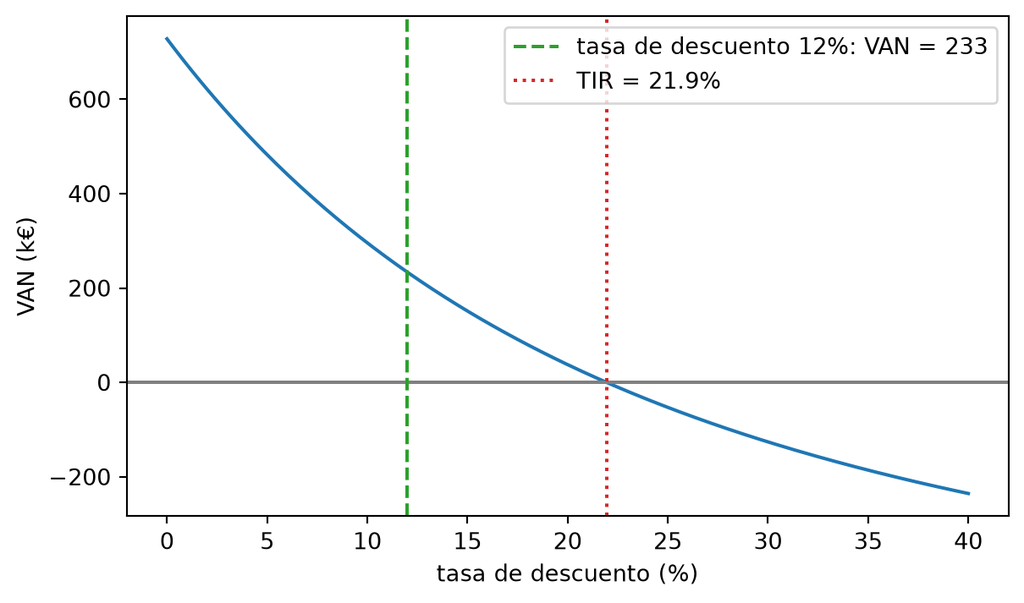

Figura 1: Perfil del VAN frente a la tasa de descuento

## Apartado 4

4. Calcule el periodo de recuperación simple y el descontado. ¿Por qué el descontado es mayor? ¿Qué información da el payback que no dan el VAN ni la TIR, y cuál omite?

El periodo de recuperación (*payback*) es el momento en que el flujo acumulado deja de ser negativo; dentro del año en que cambia de signo se interpola linealmente (se supone que el flujo de ese año llega repartido de forma uniforme). El descontado hace lo mismo con los valores actuales.

| año | flujo | acumulado | valor actual | acumulado descontado |
| --- | --- | --- | --- | --- |
| 0 | -654.8 | -654.8 | -654.8 | -654.8 |
| 1 | 154.4 | -500.4 | 137.9 | -516.9 |
| 2 | 170.2 | -330.2 | 135.7 | -381.3 |
| 3 | 187.2 | -143.0 | 133.3 | -248.0 |
| 4 | 205.6 | 62.7 | 130.7 | -117.3 |
| 5 | 225.5 | 288.2 | 128.0 | 10.7 |
| 6 | 439.8 | 728.0 | 222.8 | 233.5 |

Payback simple: el acumulado pasa de −143.0 (año 3) a 62.7 (año 4); dentro del año 4 se recuperan los 143.0 k€ que faltaban con un flujo de 205.6: payback = 3 + 143.0/205.6 = **3.70 años**. Payback descontado: el acumulado descontado pasa de −117.3 (año 4) a 10.7 (año 5); dentro del año 5 se recuperan los 117.3 k€ que faltaban con un flujo descontado de 128.0: payback = 4 + 117.3/128.0 = **4.92 años**. **Respuesta:** 3.70 años el simple y 4.92 el descontado. El descontado es mayor porque cada flujo descontado es menor que el nominal (se divide por (1 + k)^t > 1), así que hace falta más tiempo para cubrir la inversión. El payback informa de la liquidez y del riesgo de plazo (cuánto tiempo está el dinero expuesto), que no dan el VAN ni la TIR; pero ignora los flujos posteriores a la recuperación (aquí, los de los años 5 a 6, con el valor residual y la recuperación del circulante) y, en su versión simple, el valor del tiempo; por eso se usa como criterio complementario, nunca único.

## Apartado 5

5. ¿Qué supuesto del caso le parece más frágil? Compruebe cuánto cambia el VAN si las unidades del año 1 son un 15 % menores.

| año | 0 | 1 | 2 | 3 | 4 | 5 | 6 |
| --- | --- | --- | --- | --- | --- | --- | --- |
| FCL caso base | -654.8 | 154.4 | 170.2 | 187.2 | 205.6 | 225.5 | 439.8 |
| FCL con 229.5 unidades el año 1 | -645.1 | 124.8 | 138.2 | 152.7 | 168.4 | 185.3 | 380.9 |

Con las unidades del año 1 un 15 % menores (270 × 0.85 = 229.5; las de los años siguientes bajan en la misma proporción) se repite el modelo: VAN = Σ flujo_t/(1 + k)^t = −645.1 + 124.8/1.12¹ + 138.2/1.12² + 152.7/1.12³ + 168.4/1.12⁴ + 185.3/1.12⁵ + 380.9/1.12⁶ = −645.1 + 111.4 + 110.2 + 108.7 + 107.0 + 105.1 + 193.0 = **90.3 k€**. **Respuesta:** el VAN pasa de 233.5 a 90.3 k€ (-61%): sigue siendo viable. Las unidades vendidas (y el precio) son el supuesto más frágil: son previsiones de mercado, mientras que la inversión y los costes fijos están casi cerrados por contrato; un 15 % menos de volumen se lleva el 61% del VAN.